# Data driven marketing targeted towards teens

## Objective

### Selectively advertise products to teens, based on interests

### Detect mental health issues based on negative interests

## Data Exploration

This is Social Networking Sevice (SNS) data of 30,000 teenagers. There was probably some Text mining done to label the features that appreared in the SNS data and those features are in shown in the below

```r
teens <- read.csv("./data/snsdata.csv")
str(teens)
```

```
## 'data.frame':    30000 obs. of  40 variables:
##  $ gradyear    : int  2006 2006 2006 2006 2006 2006 2006 2006 2006 2006 ...
##  $ gender      : Factor w/ 2 levels "F","M": 2 1 2 1 NA 1 1 2 1 1 ...
##  $ age         : num  19 18.8 18.3 18.9 19 ...
##  $ friends     : int  7 0 69 0 10 142 72 17 52 39 ...
##  $ basketball  : int  0 0 0 0 0 0 0 0 0 0 ...
##  $ football    : int  0 1 1 0 0 0 0 0 0 0 ...
##  $ soccer      : int  0 0 0 0 0 0 0 0 0 0 ...
##  $ softball    : int  0 0 0 0 0 0 0 1 0 0 ...
##  $ volleyball  : int  0 0 0 0 0 0 0 0 0 0 ...
##  $ swimming    : int  0 0 0 0 0 0 0 0 0 0 ...
##  $ cheerleading: int  0 0 0 0 0 0 0 0 0 0 ...
##  $ baseball    : int  0 0 0 0 0 0 0 0 0 0 ...
##  $ tennis      : int  0 0 0 0 0 0 0 0 0 0 ...
##  $ sports      : int  0 0 0 0 0 0 0 0 0 0 ...
```

[output cut: 26 more lines]

So we see that most of this data is numeric. This is a good thing, since clusterting cannot be done on non-numeric catergorical data. The gender attribute is a binary variable and can be converted to numeric very easily. Infact R handles these variables and we don’t have to do any conversions and they can be tread as binary.

## Data Prep

From the summary above, we know that there is some missing data. Here we have to make a choice. We could remove the data with missing attributes, or we could do some data imputations. For large datasets, we could discard rows with missing values, as the data loss would be small relatively. However, we should alsways consider how much of the data is missing There are several methods of data imputation.

- we can replace the missing values with the median of that column.
- we can use ML to predict the missing values.

Let’s use KNN. Note that this method can be very slow and may not be the optimal method to use

```r
# missing data before KNN

# teens <- kNN(teens, variable = c("age"))
# teens <- KNN(teens, variable = c("age", "gender"))
# in the interest of saving time, I wrote the output to a and read from there. So I don't have to run KNN every time
teens <- read.csv("./data/teens_data_filled.csv")
```

Lets start the cluster analyis on only the features that represent the number of times various interests appeared on SNS profiles of teens.

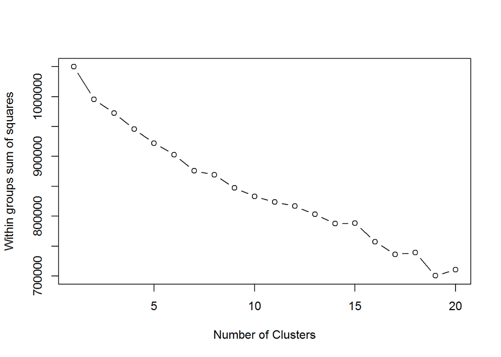

Looks like we haven’t reach the saturation point  
- We could do a PCA (Principal component Analysis) to understand some of the primary features that are responsible for the variables and discard non-contributing columns  
- We also know some columns can be merged together since they are similar in nature. For example “god”, “church” and “bible” can be combined one feature called “Religion”  
- Elimnation and construction of new features is called **feature engineering**

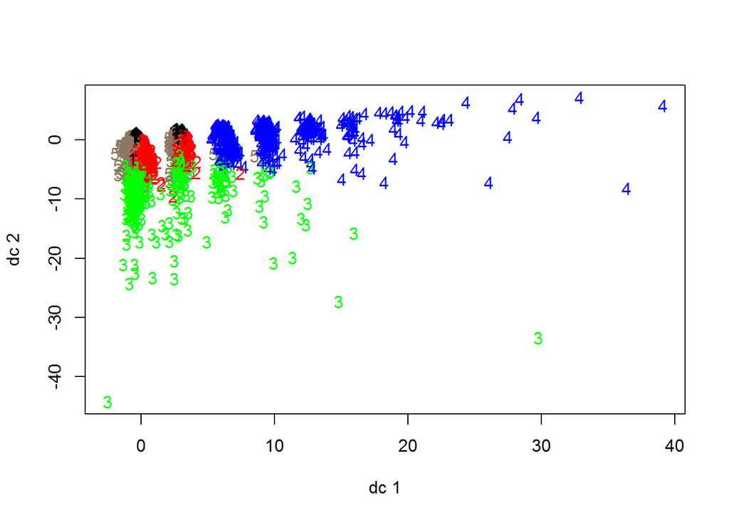

```r
#k-means
# interests_z is the data set we are performing the clustering on
# next arg is number of clusters
# iter.max number of times the cluster algrithm runs
# The number of random starting partitions when centers is a number. Trying nstart > 1 is often recommended.
# teen_km <- kmeans(interests_z, 5, iter.max = 10, nstart = 2)
#Or you can simply call: where it opitimzes all the other parameters
teen_km <- kmeans(interests_z, 5)


# k-mediods
#teen_clusters <- pam(interests_z, 5)

plotcluster(interests_z, teen_km$cluster)
```

Let us see the factor distribution each cluster

```r
par(mfrow=c(2,3))
pie(colSums(interests[teen_km$cluster==1,]), cex=4)
pie(colSums(interests[teen_km$cluster==2,]), cex=4)
pie(colSums(interests[teen_km$cluster==3,]), cex=4)
pie(colSums(interests[teen_km$cluster==4,]), cex=4)
pie(colSums(interests[teen_km$cluster==5,]), cex=4)
```

[figure not shown]